# Project: Wrangling and Analyze Data

## Assessing Data

In this section, detect and document at least **eight (8) quality issues and two (2) tidiness issue** .  
Visual assessment and programmatic assessement to assess the data.

```python
print(twitter_arch.shape)
twitter_arch.head()
```

```
(2356, 17)
```

|  | tweet_id | in_reply_to_status_id | in_reply_to_user_id | timestamp | source | text | retweeted_status_id | retweeted_status_user_id | retweeted_status_timestamp | expanded_urls | rating_numerator | rating_denominator | name | doggo | floofer | pupper | puppo |
| --- | --- | --- | --- | --- | --- | --- | --- | --- | --- | --- | --- | --- | --- | --- | --- | --- | --- |
| 0 | 892420643555336193 | NaN | NaN | 2017-08-01 16:23:56 +0000 | <a href="http://twitter.com/download/iphone" r... | This is Phineas. He's a mystical boy. Only eve... | NaN | NaN | NaN | https://twitter.com/dog_rates/status/892420643... | 13 | 10 | Phineas | None | None | None | None |
| 1 | 892177421306343426 | NaN | NaN | 2017-08-01 00:17:27 +0000 | <a href="http://twitter.com/download/iphone" r... | This is Tilly. She's just checking pup on you.... | NaN | NaN | NaN | https://twitter.com/dog_rates/status/892177421... | 13 | 10 | Tilly | None | None | None | None |
| 2 | 891815181378084864 | NaN | NaN | 2017-07-31 00:18:03 +0000 | <a href="http://twitter.com/download/iphone" r... | This is Archie. He is a rare Norwegian Pouncin... | NaN | NaN | NaN | https://twitter.com/dog_rates/status/891815181... | 12 | 10 | Archie | None | None | None | None |
| 3 | 891689557279858688 | NaN | NaN | 2017-07-30 15:58:51 +0000 | <a href="http://twitter.com/download/iphone" r... | This is Darla. She commenced a snooze mid meal... | NaN | NaN | NaN | https://twitter.com/dog_rates/status/891689557... | 13 | 10 | Darla | None | None | None | None |
| 4 | 891327558926688256 | NaN | NaN | 2017-07-29 16:00:24 +0000 | <a href="http://twitter.com/download/iphone" r... | This is Franklin. He would like you to stop ca... | NaN | NaN | NaN | https://twitter.com/dog_rates/status/891327558... | 12 | 10 | Franklin | None | None | None | None |

```python
twitter_arch.info()
```

```
<class 'pandas.core.frame.DataFrame'>
RangeIndex: 2356 entries, 0 to 2355
Data columns (total 17 columns):
 #   Column                      Non-Null Count  Dtype
---  ------                      --------------  -----
 0   tweet_id                    2356 non-null   int64
 1   in_reply_to_status_id       78 non-null     float64
 2   in_reply_to_user_id         78 non-null     float64
 3   timestamp                   2356 non-null   object
 4   source                      2356 non-null   object
 5   text                        2356 non-null   object
 6   retweeted_status_id         181 non-null    float64
 7   retweeted_status_user_id    181 non-null    float64
 8   retweeted_status_timestamp  181 non-null    object
 9   expanded_urls               2297 non-null   object
 10  rating_numerator            2356 non-null   int64
 11  rating_denominator          2356 non-null   int64
 12  name                        2356 non-null   object
 13  doggo                       2356 non-null   object
 14  floofer                     2356 non-null   object
 15  pupper                      2356 non-null   object
 16  puppo                       2356 non-null   object
dtypes: float64(4), int64(3), object(10)
memory usage: 313.0+ KB
```

```python
twitter_arch.name.value_counts()
```

```
None          745
a              55
Charlie        12
Cooper         11
Lucy           11
             ...
Dex             1
Ace             1
Tayzie          1
Grizzie         1
Christoper      1
Name: name, Length: 957, dtype: int64
```

```python
twitter_arch[twitter_arch.tweet_id.duplicated()]
```

|  | tweet_id | in_reply_to_status_id | in_reply_to_user_id | timestamp | source | text | retweeted_status_id | retweeted_status_user_id | retweeted_status_timestamp | expanded_urls | rating_numerator | rating_denominator | name | doggo | floofer | pupper | puppo |
| --- | --- | --- | --- | --- | --- | --- | --- | --- | --- | --- | --- | --- | --- | --- | --- | --- | --- |

```python
twitter_arch[['rating_numerator', 'rating_denominator']].describe()
```

|  | rating_numerator | rating_denominator |
| --- | --- | --- |
| count | 2356.000000 | 2356.000000 |
| mean | 13.126486 | 10.455433 |
| std | 45.876648 | 6.745237 |
| min | 0.000000 | 0.000000 |
| 25% | 10.000000 | 10.000000 |
| 50% | 11.000000 | 10.000000 |
| 75% | 12.000000 | 10.000000 |
| max | 1776.000000 | 170.000000 |

```python
print(image_pred.shape)
image_pred.head()
```

```
(2075, 12)
```

|  | tweet_id | jpg_url | img_num | p1 | p1_conf | p1_dog | p2 | p2_conf | p2_dog | p3 | p3_conf | p3_dog |
| --- | --- | --- | --- | --- | --- | --- | --- | --- | --- | --- | --- | --- |
| 0 | 666020888022790149 | https://pbs.twimg.com/media/CT4udn0WwAA0aMy.jpg | 1 | Welsh_springer_spaniel | 0.465074 | True | collie | 0.156665 | True | Shetland_sheepdog | 0.061428 | True |
| 1 | 666029285002620928 | https://pbs.twimg.com/media/CT42GRgUYAA5iDo.jpg | 1 | redbone | 0.506826 | True | miniature_pinscher | 0.074192 | True | Rhodesian_ridgeback | 0.072010 | True |
| 2 | 666033412701032449 | https://pbs.twimg.com/media/CT4521TWwAEvMyu.jpg | 1 | German_shepherd | 0.596461 | True | malinois | 0.138584 | True | bloodhound | 0.116197 | True |
| 3 | 666044226329800704 | https://pbs.twimg.com/media/CT5Dr8HUEAA-lEu.jpg | 1 | Rhodesian_ridgeback | 0.408143 | True | redbone | 0.360687 | True | miniature_pinscher | 0.222752 | True |
| 4 | 666049248165822465 | https://pbs.twimg.com/media/CT5IQmsXIAAKY4A.jpg | 1 | miniature_pinscher | 0.560311 | True | Rottweiler | 0.243682 | True | Doberman | 0.154629 | True |

```python
image_pred.info()
```

```
<class 'pandas.core.frame.DataFrame'>
RangeIndex: 2075 entries, 0 to 2074
Data columns (total 12 columns):
 #   Column    Non-Null Count  Dtype
---  ------    --------------  -----
 0   tweet_id  2075 non-null   int64
 1   jpg_url   2075 non-null   object
 2   img_num   2075 non-null   int64
 3   p1        2075 non-null   object
 4   p1_conf   2075 non-null   float64
 5   p1_dog    2075 non-null   bool
 6   p2        2075 non-null   object
 7   p2_conf   2075 non-null   float64
 8   p2_dog    2075 non-null   bool
 9   p3        2075 non-null   object
 10  p3_conf   2075 non-null   float64
 11  p3_dog    2075 non-null   bool
dtypes: bool(3), float64(3), int64(2), object(4)
memory usage: 152.1+ KB
```

```python
image_pred[image_pred.tweet_id.duplicated()]
```

|  | tweet_id | jpg_url | img_num | p1 | p1_conf | p1_dog | p2 | p2_conf | p2_dog | p3 | p3_conf | p3_dog |
| --- | --- | --- | --- | --- | --- | --- | --- | --- | --- | --- | --- | --- |

```python
image_pred[['img_num', 'p1_conf', 'p2_conf', 'p3_conf']].describe()
```

|  | img_num | p1_conf | p2_conf | p3_conf |
| --- | --- | --- | --- | --- |
| count | 2075.000000 | 2075.000000 | 2.075000e+03 | 2.075000e+03 |
| mean | 1.203855 | 0.594548 | 1.345886e-01 | 6.032417e-02 |
| std | 0.561875 | 0.271174 | 1.006657e-01 | 5.090593e-02 |
| min | 1.000000 | 0.044333 | 1.011300e-08 | 1.740170e-10 |
| 25% | 1.000000 | 0.364412 | 5.388625e-02 | 1.622240e-02 |
| 50% | 1.000000 | 0.588230 | 1.181810e-01 | 4.944380e-02 |
| 75% | 1.000000 | 0.843855 | 1.955655e-01 | 9.180755e-02 |
| max | 4.000000 | 1.000000 | 4.880140e-01 | 2.734190e-01 |

```python
print(tweet_json.shape)
tweet_json.head()
```

```
(2354, 3)
```

|  | tweet_id | retweet_count | fav_count |
| --- | --- | --- | --- |
| 0 | 892420643555336193 | 8853 | 39467 |
| 1 | 892177421306343426 | 6514 | 33819 |
| 2 | 891815181378084864 | 4328 | 25461 |
| 3 | 891689557279858688 | 8964 | 42908 |
| 4 | 891327558926688256 | 9774 | 41048 |

```python
tweet_json.info()
```

```
<class 'pandas.core.frame.DataFrame'>
RangeIndex: 2354 entries, 0 to 2353
Data columns (total 3 columns):
 #   Column         Non-Null Count  Dtype
---  ------         --------------  -----
 0   tweet_id       2354 non-null   int64
 1   retweet_count  2354 non-null   int64
 2   fav_count      2354 non-null   int64
dtypes: int64(3)
memory usage: 55.3 KB
```

```python
tweet_json[tweet_json.tweet_id.duplicated()]
```

|  | tweet_id | retweet_count | fav_count |
| --- | --- | --- | --- |

```python
tweet_json.describe()
```

|  | tweet_id | retweet_count | fav_count |
| --- | --- | --- | --- |
| count | 2.354000e+03 | 2354.000000 | 2354.000000 |
| mean | 7.426978e+17 | 3164.797366 | 8080.968564 |
| std | 6.852812e+16 | 5284.770364 | 11814.771334 |
| min | 6.660209e+17 | 0.000000 | 0.000000 |
| 25% | 6.783975e+17 | 624.500000 | 1415.000000 |
| 50% | 7.194596e+17 | 1473.500000 | 3603.500000 |
| 75% | 7.993058e+17 | 3652.000000 | 10122.250000 |
| max | 8.924206e+17 | 79515.000000 | 132810.000000 |

### Quality issues

##### `twitter_arch` table

1. tweet_id is an integer not a string
2. in_reply_to_status_id, in_reply_to_user_id, retweeted_status_id and retweeted_status_user_id are floats not strings
3. timestamp and retweeted_status_timestamp are strings not datetimes
4. doggo, floofer, pupper and puppo are strings not booleans
5. name column has wrong dog names
6. Some columns in the dataset not needed for the analysis
7. A row has rating_denominator equal to 0

##### `image_pred` table

1. tweet_id is an integer not a string
2. Underscore (_) between words in p1, p2 and p3 columns
3. Inconsistent case in p1, p2 and p3 columns

##### `tweet_json` table

1. tweet_id is an integer and not string

## Cleaning Data

In this section, clean **all** of the issues documented while assessing.

**Note:** A copy of the original data before cleaning be made.  
Cleaning includes merging individual pieces of data according to the rules of [tidy data](https://cran.r-project.org/web/packages/tidyr/vignettes/tidy-data.html).

```python
# Make copies of original pieces of data
twitter_arch_clean = twitter_arch.copy()
image_pred_clean = image_pred.copy()
tweet_json_clean = tweet_json.copy()
```

### Issue #1: Unwanted columns

#### Define

Remove unwanted columns in the `twitter_arch_clean` table using the drop method

#### Code

```python
twitter_arch_clean.drop(columns=['in_reply_to_status_id', 'in_reply_to_user_id', 'source', 'retweeted_status_id', 'retweeted_status_user_id', 'retweeted_status_timestamp', 'expanded_urls'], inplace=True)
```

#### Test

```python
twitter_arch_clean.sample()
```

|  | tweet_id | timestamp | text | rating_numerator | rating_denominator | name | doggo | floofer | pupper | puppo |
| --- | --- | --- | --- | --- | --- | --- | --- | --- | --- | --- |
| 986 | 749064354620928000 | 2016-07-02 02:17:13 +0000 | Meet Winston. He's pupset because I forgot to ... | 11 | 10 | Winston | None | None | None | None |

### Issue #2: Rating_denominator

#### Define:

Remove rows with thier rating_denominator equal to zero.

#### Code

```python
twitter_arch_clean = twitter_arch_clean[~(twitter_arch_clean['rating_denominator'] == 0)].copy()
```

#### Test

```python
twitter_arch_clean[(twitter_arch_clean['rating_denominator'] == 0)]
```

|  | tweet_id | timestamp | text | rating_numerator | rating_denominator | name | doggo | floofer | pupper | puppo |
| --- | --- | --- | --- | --- | --- | --- | --- | --- | --- | --- |

### Issue #3: Wrong Datatypes

#### Define:

Correct the data types in the three datasets

#### Code

```python
# integer to string
twitter_arch_clean.tweet_id = twitter_arch_clean.tweet_id.astype('str')
image_pred_clean.tweet_id = image_pred_clean.tweet_id.astype('str')
tweet_json_clean.tweet_id = tweet_json_clean.tweet_id.astype('str')

# string to datetime
twitter_arch_clean.timestamp = pd.to_datetime(twitter_arch_clean.timestamp)

# string to boolean
b={'doggo': True, 'floofer': True, 'pupper': True, 'puppo': True, 'None': False}
columns = ['doggo', 'floofer', 'pupper', 'puppo']
for column in columns:
    twitter_arch_clean[column].replace(b, inplace=True)
#twitter_arch_clean.dog_stage = twitter_arch_clean.dog_stage.astype('category')
```

#### Test

```python
print('Data type for tweet_id in the three datasets:\n', twitter_arch_clean.tweet_id.dtypes,',', image_pred_clean.tweet_id.dtypes, ',', tweet_json_clean.tweet_id.dtypes)
print()
print('Data type for timestamp in twitter_arch_clean:', twitter_arch_clean.timestamp.dtypes)
print()
print('Data type for the four dog stages:\n', twitter_arch_clean.doggo.dtypes,',', twitter_arch_clean.floofer.dtypes, ',', twitter_arch_clean.pupper.dtypes, ',' , twitter_arch_clean.puppo.dtypes)
```

```
Data type for tweet_id in the three datasets:
 object , object , object

Data type for timestamp in twitter_arch_clean: datetime64[ns, UTC]

Data type for the four dog stages:
 bool , bool , bool , bool
```

### Issue #4: Three datasets instead of one datasets

#### Define:

Merge the `tweet_json_clean` and `image_pred_clean` tables with `twitter_arch_clean` table

#### Code

```python
two_datasets = pd.merge(twitter_arch_clean, tweet_json_clean, on=['tweet_id'], how='left')
twitter_master = pd.merge(two_datasets, image_pred_clean, on=['tweet_id'], how='left')
```

#### Test

```python
twitter_master.sample()
```

|  | tweet_id | timestamp | text | rating_numerator | rating_denominator | name | doggo | floofer | pupper | puppo | ... | img_num | p1 | p1_conf | p1_dog | p2 | p2_conf | p2_dog | p3 | p3_conf | p3_dog |
| --- | --- | --- | --- | --- | --- | --- | --- | --- | --- | --- | --- | --- | --- | --- | --- | --- | --- | --- | --- | --- | --- |
| 321 | 834167344700198914 | 2017-02-21 22:26:07+00:00 | This is Sunshine. She doesn't believe in perso... | 11 | 10 | Sunshine | False | False | False | False | ... | 1.0 | ox | 0.991682 | False | bison | 0.005335 | False | water_buffalo | 0.00113 | False |

1 rows × 23 columns

### Issue #5: Wrong Names

#### Define:

Replace wrong names in the name column in the `twitter_arch_clean` table with 'None'

#### Code

```python
wrong_names = ['a', 'actually' 'all', 'an', 'by', 'getting', 'his',
               'infuriating', 'just', 'life', 'light', 'mad', 'my',
               'not', 'O', 'old', 'one', 'quite', 'such', 'the', 'this', 'very']

for i in wrong_names:
    twitter_master['name'].replace(i, 'None', inplace=True)
```

#### Test

```python
twitter_master.name.value_counts()
```

```
None          847
Charlie        12
Cooper         11
Oliver         11
Lucy           11
             ...
Gert            1
Dex             1
Ace             1
Tayzie          1
Christoper      1
Name: name, Length: 937, dtype: int64
```

### Issue #6: Underscore in names and inconsistent case

#### Define

Replace underscores in between words in columns p1, p2 and p3 in the `twitter_arch_clean` table.

#### Code

```python
twitter_master['p1'] = twitter_master['p1'].str.replace('_', ' ').str.title()
twitter_master['p2'] = twitter_master['p2'].str.replace('_', ' ').str.title()
twitter_master['p3'] = twitter_master['p3'].str.replace('_', ' ').str.title()
```

#### Test

```python
twitter_master[['p1', 'p2', 'p3']].head()
```

|  | p1 | p2 | p3 |
| --- | --- | --- | --- |
| 0 | Orange | Bagel | Banana |
| 1 | Chihuahua | Pekinese | Papillon |
| 2 | Chihuahua | Malamute | Kelpie |
| 3 | Paper Towel | Labrador Retriever | Spatula |
| 4 | Basset | English Springer | German Short-Haired Pointer |

## Storing Data

Save gathered, assessed, and cleaned master dataset to a CSV file named "twitter_archive_master.csv".

```python
twitter_master.to_csv('data/twitter_archive_master.csv', index=False)
```

## Analyzing and Visualizing Data

In this section, analyze and visualize your wrangled data.  
Produce at least **three (3) insights and one (1) visualization.**

```python
df = pd.read_csv('data/twitter_archive_master.csv')
df.head()
```

|  | tweet_id | timestamp | text | rating_numerator | rating_denominator | name | doggo | floofer | pupper | puppo | ... | img_num | p1 | p1_conf | p1_dog | p2 | p2_conf | p2_dog | p3 | p3_conf | p3_dog |
| --- | --- | --- | --- | --- | --- | --- | --- | --- | --- | --- | --- | --- | --- | --- | --- | --- | --- | --- | --- | --- | --- |
| 0 | 892420643555336193 | 2017-08-01 16:23:56+00:00 | This is Phineas. He's a mystical boy. Only eve... | 13 | 10 | Phineas | False | False | False | False | ... | 1.0 | Orange | 0.097049 | False | Bagel | 0.085851 | False | Banana | 0.076110 | False |
| 1 | 892177421306343426 | 2017-08-01 00:17:27+00:00 | This is Tilly. She's just checking pup on you.... | 13 | 10 | Tilly | False | False | False | False | ... | 1.0 | Chihuahua | 0.323581 | True | Pekinese | 0.090647 | True | Papillon | 0.068957 | True |
| 2 | 891815181378084864 | 2017-07-31 00:18:03+00:00 | This is Archie. He is a rare Norwegian Pouncin... | 12 | 10 | Archie | False | False | False | False | ... | 1.0 | Chihuahua | 0.716012 | True | Malamute | 0.078253 | True | Kelpie | 0.031379 | True |
| 3 | 891689557279858688 | 2017-07-30 15:58:51+00:00 | This is Darla. She commenced a snooze mid meal... | 13 | 10 | Darla | False | False | False | False | ... | 1.0 | Paper Towel | 0.170278 | False | Labrador Retriever | 0.168086 | True | Spatula | 0.040836 | False |
| 4 | 891327558926688256 | 2017-07-29 16:00:24+00:00 | This is Franklin. He would like you to stop ca... | 12 | 10 | Franklin | False | False | False | False | ... | 2.0 | Basset | 0.555712 | True | English Springer | 0.225770 | True | German Short-Haired Pointer | 0.175219 | True |

5 rows × 23 columns

```python
# Include rating in the dataset
df['rating'] = df.rating_numerator/df.rating_denominator
```

```python
df.tweet_id = df.tweet_id.astype('str')
df.describe()
```

|  | rating_numerator | rating_denominator | retweet_count | fav_count | img_num | p1_conf | p2_conf | p3_conf | rating |
| --- | --- | --- | --- | --- | --- | --- | --- | --- | --- |
| count | 2355.000000 | 2355.000000 | 2353.000000 | 2353.000000 | 2075.000000 | 2075.000000 | 2.075000e+03 | 2.075000e+03 | 2355.000000 |
| mean | 12.724416 | 10.459873 | 3166.107097 | 8083.442839 | 1.203855 | 0.594548 | 1.345886e-01 | 6.032417e-02 | 1.222032 |
| std | 41.527443 | 6.743226 | 5285.511567 | 11816.672682 | 0.561875 | 0.271174 | 1.006657e-01 | 5.090593e-02 | 4.083485 |
| min | 0.000000 | 2.000000 | 0.000000 | 0.000000 | 1.000000 | 0.044333 | 1.011300e-08 | 1.740170e-10 | 0.000000 |
| 25% | 10.000000 | 10.000000 | 626.000000 | 1415.000000 | 1.000000 | 0.364412 | 5.388625e-02 | 1.622240e-02 | 1.000000 |
| 50% | 11.000000 | 10.000000 | 1474.000000 | 3604.000000 | 1.000000 | 0.588230 | 1.181810e-01 | 4.944380e-02 | 1.100000 |
| 75% | 12.000000 | 10.000000 | 3652.000000 | 10132.000000 | 1.000000 | 0.843855 | 1.955655e-01 | 9.180755e-02 | 1.200000 |
| max | 1776.000000 | 170.000000 | 79515.000000 | 132810.000000 | 4.000000 | 1.000000 | 4.880140e-01 | 2.734190e-01 | 177.600000 |

```python
# Tweet with highest favorite count
df.sort_values(by=['fav_count'], ascending=False).head(1)
```

|  | tweet_id | timestamp | text | rating_numerator | rating_denominator | name | doggo | floofer | pupper | puppo | ... | p1 | p1_conf | p1_dog | p2 | p2_conf | p2_dog | p3 | p3_conf | p3_dog | rating |
| --- | --- | --- | --- | --- | --- | --- | --- | --- | --- | --- | --- | --- | --- | --- | --- | --- | --- | --- | --- | --- | --- |
| 412 | 822872901745569793 | 2017-01-21 18:26:02+00:00 | Here's a super supportive puppo participating ... | 13 | 10 | None | False | False | False | True | ... | Lakeland Terrier | 0.196015 | True | Labrador Retriever | 0.160329 | True | Irish Terrier | 0.069126 | True | 1.3 |

1 rows × 24 columns

```python
# Tweet with highest retweet count
df.sort_values(by=['retweet_count'], ascending=False).head(1)
```

|  | tweet_id | timestamp | text | rating_numerator | rating_denominator | name | doggo | floofer | pupper | puppo | ... | p1 | p1_conf | p1_dog | p2 | p2_conf | p2_dog | p3 | p3_conf | p3_dog | rating |
| --- | --- | --- | --- | --- | --- | --- | --- | --- | --- | --- | --- | --- | --- | --- | --- | --- | --- | --- | --- | --- | --- |
| 1038 | 744234799360020481 | 2016-06-18 18:26:18+00:00 | Here's a doggo realizing you can stand in a po... | 13 | 10 | None | True | False | False | False | ... | Labrador Retriever | 0.825333 | True | Ice Bear | 0.044681 | False | Whippet | 0.018442 | True | 1.3 |

1 rows × 24 columns

```python
# Tweet with highest rating count
df.sort_values(by=['rating'], ascending=False).head(1)
```

|  | tweet_id | timestamp | text | rating_numerator | rating_denominator | name | doggo | floofer | pupper | puppo | ... | p1 | p1_conf | p1_dog | p2 | p2_conf | p2_dog | p3 | p3_conf | p3_dog | rating |
| --- | --- | --- | --- | --- | --- | --- | --- | --- | --- | --- | --- | --- | --- | --- | --- | --- | --- | --- | --- | --- | --- |
| 978 | 749981277374128128 | 2016-07-04 15:00:45+00:00 | This is Atticus. He's quite simply America af.... | 1776 | 10 | Atticus | False | False | False | False | ... | Bow Tie | 0.533941 | False | Sunglasses | 0.080822 | False | Sunglass | 0.050776 | False | 177.6 |

1 rows × 24 columns

```python
# Names pet owners gave to their dogs and the counts
df.name.value_counts().sort_values(ascending=False).head(10)
```

```
None       847
Charlie     12
Cooper      11
Oliver      11
Lucy        11
Tucker      10
Lola        10
Penny       10
Winston      9
Bo           9
Name: name, dtype: int64
```

```python
# Get dog breeds in that was predicted
dog_breeds_1,dog_breeds_2, dog_breeds_3 = [], [], []
for i in range(len(df)):
    if df.p1_dog[i] == True:
        dog_breeds_1.append(df.iloc[i].p1)
    elif df.p2_dog[i] == True:
        dog_breeds_2.append(df.iloc[i].p2)
    elif df.p3_dog[i] == True:
        dog_breeds_3.append(df.iloc[i].p3)
dog_breeds = dog_breeds_1 + dog_breeds_2 + dog_breeds_3
```

```python
print('There was about {} dog breeds predictions when p1, p2 and p3 were combined with {} distinct breeds in the list.'.format(len(dog_breeds), len(np.unique(dog_breeds))))
```

```
There was about 1751 dog breeds predictions when p1, p2 and p3 were combined with 113 distinct breeds in the list.
```

```python
# Create a dataframe of breeds and their count using the first prediction
breeds_df = pd.DataFrame.from_dict(Counter(dog_breeds_1), orient='index').reset_index()
breeds_df.rename(columns={'index':'breed', 0:'count'}, inplace=True)

breeds_df.sort_values(by=['count'], ascending=False).head(10)
```

|  | breed | count |
| --- | --- | --- |
| 9 | Golden Retriever | 150 |
| 16 | Labrador Retriever | 100 |
| 6 | Pembroke | 89 |
| 0 | Chihuahua | 83 |
| 14 | Pug | 57 |
| 19 | Chow | 44 |
| 7 | Samoyed | 43 |
| 70 | Toy Poodle | 39 |
| 4 | Pomeranian | 38 |
| 17 | Malamute | 30 |

```python
print('The correlation between retweet count and favorite count is {:.3f}'.format(df['retweet_count'].corr(df['fav_count'])))
```

```
The correlation between retweet count and favorite count is 0.703
```

### Insights:

1. Dog owner had named dog names that were not unique with the common names like Charlie, Cooper, Oliver, Lucy, Tucker and Lola.
2. There were about 1751 dog breeds predictions when p1, p2 and p3 were combined with 113 distinct breeds in the list.
3. The two most popular dog breed in the first prediction was Golden Retriever and Labrador Retriever.
4. Retweet count and favorite count had a positive correlation.

### Visualization

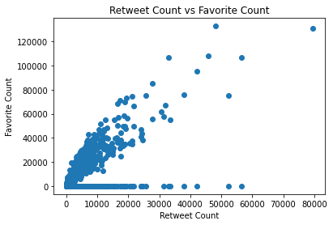

```python
plt.title('Retweet Count vs Favorite Count')
plt.xlabel('Retweet Count')
plt.ylabel('Favorite Count')
plt.scatter(data=df, x='retweet_count', y='fav_count');
plt.savefig('image/RetweetFavorite.jpg', bbox_inches='tight')
```

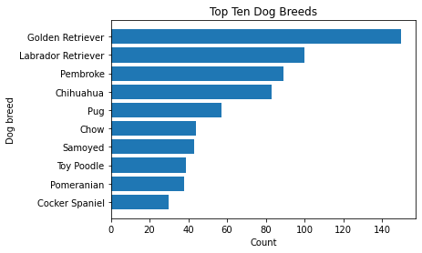

```python
# Top ten dog breeds based on the first prediction
a=breeds_df.sort_values(by='count').tail(10)
plt.ylabel('Dog breed')
plt.xlabel('Count')
plt.title('Top Ten Dog Breeds')
plt.barh(a['breed'], a['count']);
plt.savefig('image/TopDogBreeds.jpg', bbox_inches='tight')
```

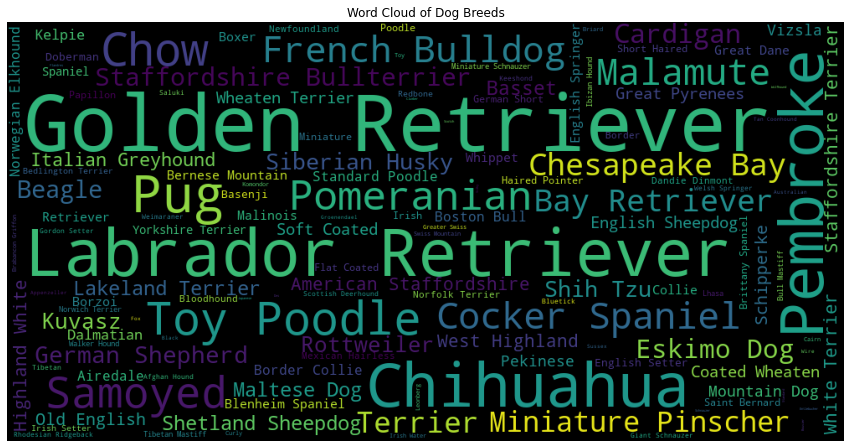

```python
unique_string=(' ').join(dog_breeds)
wordcloud = WordCloud(width=1000, height=500).generate(unique_string)
plt.figure(figsize=(15,8))
plt.title('Word Cloud of Dog Breeds')
plt.axis('off')
plt.imshow(wordcloud);
plt.savefig('image/wordcloud.jpg')
```